# Assignment 11: Detecting Overfitting and Overfitting Issues

Ramya Pinninti

## **Assignment Objectives**

- Enhance understanding the procedure of likelihood-based chi-square hypothesis testing .
- Implement the procedures for detecting overfitting/underfitting issues in practical applications.

## **Policies of Using AI Tools**

**Policy on AI Tool Use**: Please adhere to the AI tool policy specified in the course syllabus. The direct copying of AI-generated content is strictly prohibited. All submitted work must reflect your own understanding; where external tools are consulted, content must be thoroughly rephrased and synthesized in your own words.

**Code Inclusion Requirement**: Any code included in your essay must be properly commented to explain the purpose and/or expected output of key code lines. Submitting AI-generated code without meaningful, student-added comments will not be accepted.

## Testing Overfitting/Underfitting

In Machine Learning and Statistics, overfitting occurs when a model is too complex and learns noise, leading to poor performance on new data, while underfitting happens when a model is too simple to capture important patterns, resulting in high errors overall; both issues are explained by the Bias–Variance Tradeoff and can cause unreliable predictions in real-world applications.

The probability density function (PDF) of the Weibull distribution is:

$$f(t; \lambda, \beta) = \frac{\beta}{\lambda} \left( \frac{t}{\lambda}
\right)^{\beta-1} \exp\left[ -\left( \frac{t}{\lambda} \right)^\beta
\right], \quad t \ge 0$$
where $\lambda > 0$ is the scale parameter (characteristic life) and $\beta > 0$ is the shape parameter.

When $\beta = 1$, the Weibull PDF simplifies to the exponential PDF:

$$f(t; \lambda) = \frac{1}{\lambda} \exp\left( -\frac{t}{\lambda} \right)$$
with constant hazard rate $h(t) = 1/\lambda$.

**This assignment focuses on performing a hypothesis test for the shape parameter ($\beta$) of the Weibull distribution within a reliability mode**

$$\begin{align}
H_0&: \beta = 1 \quad \text{(Exponential model, simpler)} \\
H_1&: \beta \neq 1 \quad \text{(Weibull model, more complex)}
\end{align}$$

## **Question: Reliability Application**

A mid-sized manufacturing company producing industrial conveyor systems began experiencing unexpected downtime in one of its distribution facilities, prompting concern about the reliability of a newly sourced batch of ball bearings used in the motor assemblies. These bearings, supplied by a vendor adopting cost-saving production methods, were installed across multiple units operating under continuous load conditions. After several months, maintenance logs revealed a pattern of increasing failures, with components lasting anywhere from a few dozen to over 150 hours before breakdown. To investigate, the engineering team collected time-to-failure data from 50 identical bearings and conducted a Weibull analysis within the framework of Reliability Engineering. The 50 time-to-failure (survival time) are:

```
12.4, 18.7, 25.3, 30.1, 33.5, 35.2, 38.9, 40.3, 42.7, 45.1, 47.6, 49.8, 52.4, 55.0,
57.3, 60.2, 62.8, 65.1, 67.9, 70.5, 72.3, 75.6, 78.2, 80.9, 83.4, 85.7, 88.1, 90.6,
93.2, 95.8, 98.4, 101.0, 104.5, 107.3, 110.6, 113.2, 116.8, 120.1, 123.7, 127.4,
130.9, 134.5, 138.2, 142.0, 146.3, 150.7, 155.2, 160.8, 168.4, 175.9
```

This assignment focuses on hypothesis $H_0: \beta = 1$ (exponential) against $H_1: \beta \neq 1$ (Weibull). This framework detects overfitting (fitting a Weibull when exponential is true) and underfitting (fitting exponential when Weibull with $\beta \neq 1$ is true).

a). Find the MLE of the Weibull parameters $\lambda$ (scale) and $\beta$ (shape), denoted by $\hat{\lambda}$ and $\hat{\beta}$, respectively, using the `optim()` procedure. [*Hint: You should provide explicit expressions for the log-likelihood and gradient functions of the Weibull distribution parameters.*]

```r
# We plug in our sample data, with the goal of analyzing time-to-failure using a Weibull distribution
#Weibull shape parameter determines failure behavior
#Here we are returning to MLE parameter estimations
#in order to test H0: B = 1 (exponential)
#and H1: B ≠ 1 (Weibull)

sample.data <- c(
  12.4, 18.7, 25.3, 30.1, 33.5, 35.2, 38.9, 40.3, 42.7, 45.1,
  47.6, 49.8, 52.4, 55.0, 57.3, 60.2, 62.8, 65.1, 67.9, 70.5,
  72.3, 75.6, 78.2, 80.9, 83.4, 85.7, 88.1, 90.6, 93.2, 95.8,
  98.4, 101.0, 104.5, 107.3, 110.6, 113.2, 116.8, 120.1, 123.7, 127.4,130.9, 134.5, 138.2, 142.0, 146.3, 150.7, 155.2, 160.8, 168.4, 175.9)

#Weibull MLE estimation
#The likelihood function measures how likely the
#observed data is given the parameters

#Here we maximize the log-likelihood to ensure
#numeric stability and easier differentiation
w.loglik <- function(params, data) {

  shape <- params[1] #shape or Beta
  scale <- params[2] #scale or lambda
  n <- length(data) #sample size

  # Weibull log-likelihood derived from PDF:
  # f(t) = (β/λ)(t/λ)^(β-1) exp(-(t/λ)^β)


  loglik <- (
         n * log(shape) - n * shape * log(scale) +
         (shape - 1) * sum(log(data)) -
         sum((data / scale)^shape)
          )

  return(loglik)
}

# The score function is the first derivative of
#the log-likelihood. It can be used to efficiently find MLE values
w.score <- function(params, data) {

  shape <- params[1]
  scale <- params[2]
  n <- length(data)

  #derivative wrt shape
  grad_shape <- (
    n/shape - n * log(scale) +
    sum(log(data)) -
    sum((data / scale)^shape * log(data / scale))
  )

  #derivative wrt scale
  grad_scale <- (
    -(n * shape)/scale +
    (shape/scale) * sum((data / scale)^shape)
  )

  return(c(grad_shape, grad_scale))
}

initial.params <- c(shape = 1.5, scale = mean(sample.data))

# optimization of MLE to find parameter values that
# maximize log-likelihood

w.mle <- optim(
  par = initial.params,
  fn = w.loglik,
  gr = w.score, #gradient/score function created
  data = sample.data, #data passed into function
  method = "L-BFGS-B", #optimization method
  control = list(fnscale = -1,
                 maxit = 500,
                 abstol = 1e-8),
  hessian = TRUE
)


w.ll <- w.mle$value #maximized log likelihood
```

b). Find the MLE of the exponential parameter $\lambda$ (scale), denoted by $\hat{\lambda}$, using any procedure. [*Hint: You should provide explicit expressions for the log-likelihood and gradient functions of the exponential distribution parameters.*]

```r
# Under H0: β = 1, Weibull reduces to Exponential distribution:
exp.loglik <- function(lambda, data) {

  n <- length(data)

  # exponential log-likelihood
  loglik <- (
    -n * log(lambda) -
    sum(data / lambda)
  )

  return(loglik)
}


exp.score <- function(lambda, data) {

  n <- length(data)

  # derivative of exponential log-likelihood
  grad <- (
    -n / lambda +
    sum(data) / (lambda^2)
  )

  return(grad)
}



# MLE for exponential model
exp.mle <- optim(
  par = mean(sample.data),   # initial guess
  fn = exp.loglik,
  gr = exp.score,
  data = sample.data,
  method = "L-BFGS-B",
  control = list(fnscale = -1)
)


exp.ll <- exp.mle$value
```

c). Perform the likelihood ratio $\chi^2$ test on $\beta = 1$. What is the p-value? [*Hint: Use the results in a) and b)*.]

```r
LR.stat <- 2 * (w.ll - exp.ll)

p.value.lrt <- 1 - pchisq(LR.stat, df = 1)
```

d). Perform the Wald $\chi^2$ on the same hypothesis $\beta = 1$. What is the p-value? [*Hint: You need to find the observed Fisher information matrix (i.e., the negative Hessian matrix from `optim()`) based on the Weibull distribution. The inverse of the negative observed Hessian matrix is the covariance matrix*.]

```r
# Wald test uses:
#   (β̂ - 1)^2 / Var(β̂)
#
# Variance comes from Fisher Information:
#   I(θ) ≈ -Hessian(log-likelihood)

hessian <- w.mle$hessian

# covariance matrix = inverse of negative Hessian
cov.mat <- solve(-hessian)

# standard error of β̂
se.beta <- sqrt(cov.mat[1,1])

beta.hat <- w.mle$par[1]

wald.stat <- (beta.hat - 1)^2 / (se.beta^2)

p.value.wald <- 1 - pchisq(wald.stat, df = 1)
```

e). Write a summary of the above analyses to address the following:

- Whether the two tests generated the same results.
- Which model is recommended for the data.
- Draw the density curve based on the MLE(s) of the parameter(s) and describe the distribution of the time-to-failure.

The Likelihood Ratio Test (LRT) and the Wald Test were both used to evaluate the null hypothesis below. Ho: β = 1, exponential model H1: β ≠ 1 (Weibull)

LRT statistic = 34.45, p-value = 4.37 × 10⁻⁹ Wald statistic = 23.11, p-value = 1.53 × 10⁻⁶

Both p-values are extremely small and the tests lead to the same conclusion of rejecting Ho. The agreement is expected, as both tests are asymptotically equivalent.

The recommended model is the Weibull model. The estimated Weibull parameters are: β-hat =2.206 λ-hat =99.02

The assumption of a constant failure rate, under the exponential model, is inconsistent with the given data.

A density curve was constructed based on the observed MLEs. The exponential model assigns highest failure density at time zero and decays monotonically due to its constant hazard assumption, whereas the Weibull model with B-hat >1 , reflects an increasing hazard rate, producing a unimodal density that captures the behavior observed in the data.

```r
#results

results <- list(


  # Weibull MLE Results

  Weibull = list(
    shape_beta_hat = w.mle$par[1],
    scale_lambda_hat = w.mle$par[2],
    log_likelihood = w.ll
  ),


  # Exponential MLE Results

  Exponential = list(
    lambda_hat = exp.mle$par,
    log_likelihood = exp.ll
  ),


  # Likelihood Ratio Test

  Likelihood_Ratio_Test = list(
    test_statistic = LR.stat,
    df = 1,
    p_value = p.value.lrt
  ),

  # Wald

  Wald_Test = list(
    beta_hat = beta.hat,
    standard_error = se.beta,
    test_statistic = wald.stat,
    df = 1,
    p_value = p.value.wald
  ),


  # Covariance Matrix (from Hessian)

  Covariance_Matrix = cov.mat
)


results
```

```
$Weibull
$Weibull$shape_beta_hat
   shape
2.206004

$Weibull$scale_lambda_hat
   scale
99.02077

$Weibull$log_likelihood
[1] -256.4198


$Exponential
$Exponential$lambda_hat
[1] 87.61

$Exponential$log_likelihood
[1] -273.6448


$Likelihood_Ratio_Test
$Likelihood_Ratio_Test$test_statistic
[1] 34.44995

$Likelihood_Ratio_Test$df
[1] 1

$Likelihood_Ratio_Test$p_value
[1] 4.373531e-09


$Wald_Test
$Wald_Test$beta_hat
   shape
2.206004

$Wald_Test$standard_error
[1] 0.2508635

$Wald_Test$test_statistic
   shape
23.11119

$Wald_Test$df
[1] 1

$Wald_Test$p_value
       shape
1.528983e-06


$Covariance_Matrix
           shape     scale
shape 0.06293251  0.521004
scale 0.52100402 44.610560
```

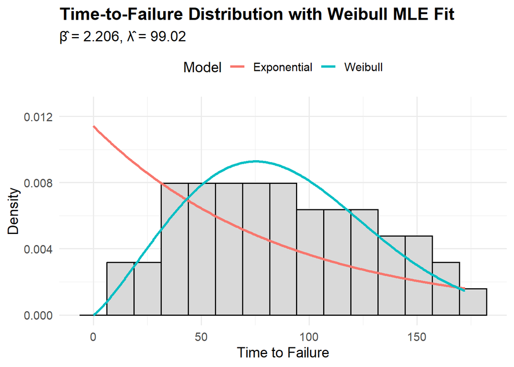

```r
# -----------------------------------------
# Load library
# -----------------------------------------
library(ggplot2)

# -----------------------------------------
# Extract MLE estimates
# -----------------------------------------
beta.hat <- w.mle$par[1]
lambda.hat <- w.mle$par[2]

# Exponential MLE (for comparison)
lambda.exp <- exp.mle$par


t.seq <- seq(0, quantile(sample.data, 0.99), length.out = 500)

# Weibull density
weibull.df <- data.frame(
  time = t.seq,
  density = dweibull(t.seq, shape = beta.hat, scale = lambda.hat),
  model = "Weibull"
)

# Exponential density
exp.df <- data.frame(
  time = t.seq,
  density = dexp(t.seq, rate = 1 / lambda.exp),
  model = "Exponential"
)


plot.df <- rbind(weibull.df, exp.df)


y.max <- max(plot.df$density) * 1.1


ggplot() +


  geom_histogram(
    data = data.frame(sample.data),
    aes(x = sample.data, y = ..density..),
    bins = 15,
    fill = "gray85",
    color = "black"
  ) +


  geom_line(
    data = plot.df,
    aes(x = time, y = density, color = model),
    size = 1.2
  ) +

  # Labels
  labs(
    title = "Time-to-Failure Distribution with Weibull MLE Fit",
    subtitle = paste0("β̂ = ", round(beta.hat, 3),
                      ", λ̂ = ", round(lambda.hat, 2)),
    x = "Time to Failure",
    y = "Density",
    color = "Model"
  ) +


  theme_minimal(base_size = 14) +
  theme(
    plot.title = element_text(face = "bold"),
    legend.position = "top"
  ) +


  coord_cartesian(ylim = c(0, y.max))
```